# Topic 3.2: Cost-Sensitive Learning

Handling Imbalanced Classes and Unequal Error Costs

Advanced Modelling, Master in Computational Social Science

UC3M, 2026

# 1 Introduction

In this notebook, we will focus on **cost-sensitive learning** for classification problems with imbalanced classes and asymmetric error costs.

```r
# Core packages
library(tidyverse)    # Data manipulation and visualization
library(caret)        # Model training and evaluation
library(pROC)         # ROC curve analysis

# Visualization
library(ggplot2)
library(patchwork)
library(viridis)

# Set seed for reproducibility
set.seed(42)
```

We will also define two helper functions.

```r
# Theoretical decision threshold from the cost matrix in binary classification
# c00: TN cost, c01: FP cost, c10: FN cost, c11: TP cost
theoretical_threshold <- function(c01, c10, c00 = 0, c11 = 0) {
  numerator <- c01 - c00
  denominator <- (c01 - c00) + (c10 - c11)

  if (denominator <= 0) {
    stop("Invalid costs: denominator must be positive.")
  }

  numerator / denominator
}

# Expected cost using a cost matrix with:
# rows = actual class, columns = predicted class
expected_cost <- function(pred, actual, cost_matrix, normalize = TRUE) {

  actual <- factor(actual, levels = rownames(cost_matrix))
  pred <- factor(pred, levels = colnames(cost_matrix))

  cm <- table(actual, pred)
  total_cost <- sum(cm * cost_matrix)

  if (normalize) total_cost / sum(cm) else total_cost
}
```

# 2 The Problem of Imbalanced Classes: Simulated Credit Card Fraud Example

In many real-world problems, classes are not equally distributed. This causes standard classifiers to: - Favor the majority class - Achieve high overall accuracy while performing poorly on minority classes

We will generate a simulated dataset to study imbalance problems, supposing that we have a binary classification problem related with credit card fraud.

```r
# Create an imbalanced dataset
set.seed(42)
n <- 1000

# Generate features
X1 <- c(rnorm(950, mean = 0, sd = 1), rnorm(50, mean = 2, sd = 1.5))
X2 <- c(rnorm(950, mean = 0, sd = 1), rnorm(50, mean = 1.5, sd = 1.5))

# Create dataset
imbalanced_data <- data.frame(
  X1 = X1,
  X2 = X2,
  Class = factor(c(rep("Legitimate", 950), rep("Fraud", 50)),
                 levels = c("Legitimate", "Fraud"))
)

# Check class distribution
table(imbalanced_data$Class)
```

```
##
## Legitimate      Fraud
##        950         50
```

```r
prop.table(table(imbalanced_data$Class))
```

```
##
## Legitimate      Fraud
##       0.95       0.05
```

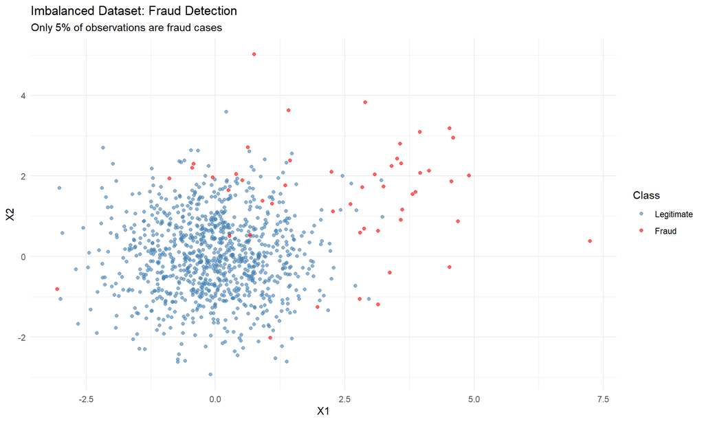

```r
# Visualize
ggplot(imbalanced_data, aes(x = X1, y = X2, color = Class)) +
  geom_point(alpha = 0.6) +
  labs(title = "Imbalanced Dataset: Fraud Detection",
       subtitle = "Only 5% of observations are fraud cases") +
  theme_minimal() +
  scale_color_manual(values = c("Fraud" = "red", "Legitimate" = "steelblue"))
```

## 2.1 The Problem with Standard Classification

We first fit a logistic regression directly on the data

```r
# Split data
set.seed(123)
train_idx <- createDataPartition(imbalanced_data$Class, p = 0.7, list = FALSE)
train_imb <- imbalanced_data[train_idx, ]
test_imb <- imbalanced_data[-train_idx, ]

# Train a standard logistic regression with cross validation
logit_standard <- train(Class ~ X1 + X2,
                        data = train_imb,
                        method = "glm",
                        family = binomial(),
                        trControl = trainControl(method = "cv", number = 5))

# Predictions
pred_standard <- predict(logit_standard, test_imb)

# Confusion matrix
cm_standard <- confusionMatrix(pred_standard, test_imb$Class, positive = "Fraud")
cm_standard
```

```
## Confusion Matrix and Statistics
##
##             Reference
## Prediction   Legitimate Fraud
##   Legitimate        284     7
##   Fraud               1     8
##
##                Accuracy : 0.9733
##                  95% CI : (0.9481, 0.9884)
##     No Information Rate : 0.95
##     P-Value [Acc > NIR] : 0.03407
##
##                   Kappa : 0.6537
##
##  Mcnemar's Test P-Value : 0.07710
##
##             Sensitivity : 0.53333
##             Specificity : 0.99649
##          Pos Pred Value : 0.88889
##          Neg Pred Value : 0.97595
##              Prevalence : 0.05000
##          Detection Rate : 0.02667
##    Detection Prevalence : 0.03000
##       Balanced Accuracy : 0.76491
##
##        'Positive' Class : Fraud
##
```

**Problem**: High accuracy but poor fraud detection

## 2.2 Solution 1: Adjusting the Decision Threshold

Instead of using 0.5 as the threshold, we can lower it to catch more positive cases.

```r
# Get probability predictions from logistic regression
logit_prob <- train(Class ~ X1 + X2,
                    data = train_imb,
                    method = "glm",
                    family = binomial(),
                    trControl = trainControl(method = "cv", number = 5, classProbs = TRUE))

# Get probabilities
probs <- predict(logit_prob, test_imb, type = "prob")
head(probs)
```

```
##    Legitimate      Fraud
## 1   0.6605684 0.33943157
## 3   0.9687043 0.03129566
## 4   0.9747655 0.02523449
## 7   0.9335628 0.06643722
## 9   0.9505339 0.04946613
## 12  0.8822941 0.11770595
```

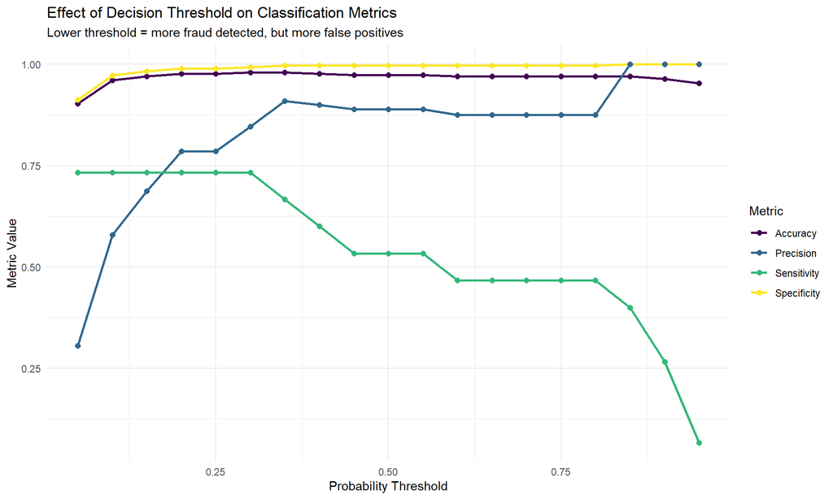

```r
# Evaluate different thresholds
thresholds <- seq(0.05, 0.95, by = 0.05)
results <- data.frame()

for (thresh in thresholds) {
  pred <- ifelse(probs$Fraud > thresh, "Fraud", "Legitimate")
  pred <- factor(pred, levels = c("Legitimate", "Fraud"))

  cm <- confusionMatrix(pred, test_imb$Class, positive = "Fraud")

  results <- rbind(results, data.frame(
    Threshold = thresh,
    Accuracy = cm$overall["Accuracy"],
    Sensitivity = cm$byClass["Sensitivity"],  # True Positive Rate
    Specificity = cm$byClass["Specificity"],   # True Negative Rate
    Precision = cm$byClass["Precision"]
  ))
}

# Visualize threshold effects
results_long <- results %>%
  pivot_longer(cols = -Threshold, names_to = "Metric", values_to = "Value")

ggplot(results_long, aes(x = Threshold, y = Value, color = Metric)) +
  geom_line(linewidth = 1) +
  geom_point(size = 2) +
  labs(title = "Effect of Decision Threshold on Classification Metrics",
       subtitle = "Lower threshold = more fraud detected, but more false positives",
       x = "Probability Threshold", y = "Metric Value") +
  theme_minimal() +
  scale_color_viridis_d()
```

Another way of choosing the threshold is using the **ROC curve**, which shows the tradeoff between sensitivity and specificity across all thresholds.

Using the `proc::coords()` function we can get the optimal threshold according to several methods, such as the Youden’s J statistic. (See https://www.rdocumentation.org/packages/pROC/versions/1.19.0.1/topics/coords for details).

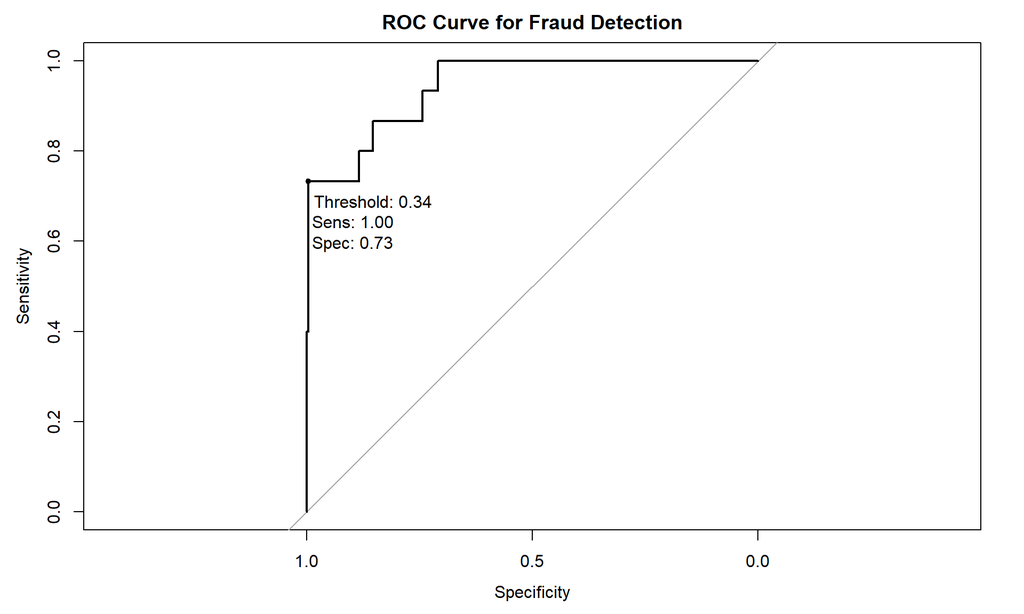

```r
# Calculate ROC curve
roc_obj <- roc(test_imb$Class, probs$Fraud, levels = c("Legitimate", "Fraud"))

# Plot ROC curve
plot(roc_obj, main = "ROC Curve for Fraud Detection",
     print.thres = TRUE, print.thres.pattern = "Threshold: %.2f\nSens: %.2f\nSpec: %.2f")
```

```r
# Area Under Curve
cat("\nAUC:", auc(roc_obj), "\n")
```

```
##
## AUC: 0.9447953
```

```r
# Find optimal threshold (Youden's J statistic)
coords <- coords(roc_obj, "best", ret = c("threshold", "sensitivity", "specificity"))
cat("Optimal threshold:", coords$threshold, "\n")
```

```
## Optimal threshold: 0.3438078
```

```r
cat("At this threshold - Sensitivity:", coords$sensitivity, ", Specificity:", coords$specificity, "\n")
```

```
## At this threshold - Sensitivity: 0.7333333 , Specificity: 0.9964912
```

## 2.3 Solution 2: Cost-Sensitive Learning

When different errors have different costs, we should minimize **expected cost** instead of error rate.

Consider the following costs: - **False Negative** (missing fraud): Very costly (loosing money due to the fraud) - Cost = 100 - **False Positive** (treating a legitimate case as fraud): Moderate cost (checking details to confirm it was legitimate) - Cost = 10 - **True Positive/Negative**: No cost = 0

```r
# Define cost matrix using the same convention as the slides:
# rows = actual class, columns = predicted class
cost_matrix <- matrix(c(
  0,  10,   # Actual Legitimate: TN = 0, FP = 10
  100, 0    # Actual Fraud: FN = 100, TP = 0
), nrow = 2, byrow = TRUE,
dimnames = list(
  Actual = c("Legitimate", "Fraud"),
  Predicted = c("Legitimate", "Fraud")
))

cat("Cost Matrix:\n")
```

```
## Cost Matrix:
```

```r
print(cost_matrix)
```

```
##             Predicted
## Actual       Legitimate Fraud
##   Legitimate          0    10
##   Fraud             100     0
```

Remember how we derived the optimal thresholds given a cost matrix. For a binary classifier with $p = P(Y=1\mid x)$, we compare:

$$R(0\mid x) = P(Y=0\mid x)c_{00} + P(Y=1\mid x)c_{10}$$
$$R(1\mid x) = P(Y=0\mid x)c_{01} + P(Y=1\mid x)c_{11}$$

Predict class $1$ when $R(1\mid x) \le R(0\mid x)$, which yields:

$$p^* = \frac{c_{01} - c_{00}}{(c_{01} - c_{00}) + (c_{10} - c_{11})}$$

If $c_{00}=c_{11}=0$, this simplifies to $p^* = \frac{c_{01}}{c_{01}+c_{10}}$.

```r
# Extract c_ij values from the matrix
c00 <- cost_matrix["Legitimate", "Legitimate"]  # TN cost
c01 <- cost_matrix["Legitimate", "Fraud"]       # FP cost
c10 <- cost_matrix["Fraud", "Legitimate"]       # FN cost
c11 <- cost_matrix["Fraud", "Fraud"]            # TP cost

p_star_theory <- theoretical_threshold(c01 = c01, c10 = c10, c00 = c00, c11 = c11)

cat(sprintf("Theoretical threshold for this matrix: %.3f\n", p_star_theory))
```

```
## Theoretical threshold for this matrix: 0.091
```

However, this optimal value assumed one important thing: that we knew the theoretical posterior probabilities.

In practice, we can evaluate a grid of thresholds and choose the one that minimizes the expected cost value.

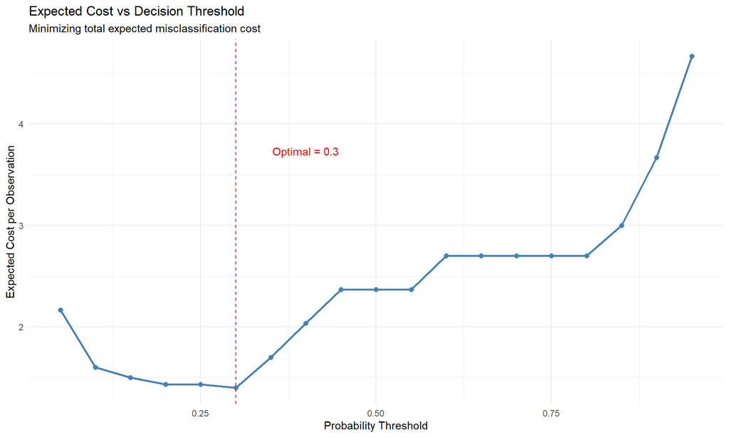

```r
# Evaluate expected cost on a threshold grid
cost_results <- data.frame()

for (thresh in thresholds) {
  pred <- ifelse(probs$Fraud > thresh, "Fraud", "Legitimate")
  pred <- factor(pred, levels = c("Legitimate", "Fraud"))

  expected_cost_value <- expected_cost(
    pred = pred,
    actual = test_imb$Class,
    cost_matrix = cost_matrix,
    normalize = TRUE
  )

  cost_results <- rbind(cost_results, data.frame(
    Threshold = thresh,
    Expected_Cost = expected_cost_value
  ))
}

# Find optimal threshold
optimal_thresh <- cost_results$Threshold[which.min(cost_results$Expected_Cost)]

# Plot
ggplot(cost_results, aes(x = Threshold, y = Expected_Cost)) +
  geom_line(color = "steelblue", linewidth = 1) +
  geom_point(color = "steelblue", size = 2) +
  geom_vline(xintercept = optimal_thresh, linetype = "dashed", color = "red") +
  annotate("text", x = optimal_thresh + 0.1, y = max(cost_results$Expected_Cost) * 0.8,
           label = paste("Optimal =", optimal_thresh), color = "red") +
  labs(title = "Expected Cost vs Decision Threshold",
       subtitle = "Minimizing total expected misclassification cost",
       x = "Probability Threshold", y = "Expected Cost per Observation") +
  theme_minimal()
```

```r
cat("Cost-optimal threshold:", optimal_thresh, "\n")
```

```
## Cost-optimal threshold: 0.3
```

```r
cat("Minimum expected cost:", min(cost_results$Expected_Cost), "\n")
```

```
## Minimum expected cost: 1.4
```

```r
cat("Theoretical threshold from cost matrix:", round(p_star_theory, 3), "\n")
```

```
## Theoretical threshold from cost matrix: 0.091
```

## 2.4 Solution 3: Adjusting Prior Probabilities (Bayes Classifiers)

We saw that in Bayesian classifiers we can use balanced priors instead of sample priors.

```r
# LDA with empirical priors (sample imbalance)
lda_emp <- MASS::lda(Class ~ X1 + X2, data = train_imb)

# LDA with balanced priors
lda_bal <- MASS::lda(Class ~ X1 + X2, data = train_imb, prior = c(0.5, 0.5))

pred_lda_emp <- predict(lda_emp, test_imb)$class
pred_lda_bal <- predict(lda_bal, test_imb)$class

cm_lda_emp <- confusionMatrix(pred_lda_emp, test_imb$Class, positive = "Fraud")
cm_lda_bal <- confusionMatrix(pred_lda_bal, test_imb$Class, positive = "Fraud")

# Show confusion matrices to inspect the FN/FP trade-off directly
knitr::kable(cm_lda_emp$table,
             caption = "Confusion Matrix: LDA with Empirical Priors")
```

Confusion Matrix: LDA with Empirical Priors

|  | Legitimate | Fraud |
| --- | --- | --- |
| Legitimate | 284 | 5 |
| Fraud | 1 | 10 |

```r
knitr::kable(cm_lda_bal$table,
             caption = "Confusion Matrix: LDA with Balanced Priors")
```

Confusion Matrix: LDA with Balanced Priors

|  | Legitimate | Fraud |
| --- | --- | --- |
| Legitimate | 275 | 4 |
| Fraud | 10 | 11 |

```r
prior_comparison <- tibble(
  Model = c("LDA (empirical priors)", "LDA (balanced priors)"),
  Accuracy = c(cm_lda_emp$overall["Accuracy"], cm_lda_bal$overall["Accuracy"]),
  Sensitivity = c(cm_lda_emp$byClass["Sensitivity"], cm_lda_bal$byClass["Sensitivity"]),
  Specificity = c(cm_lda_emp$byClass["Specificity"], cm_lda_bal$byClass["Specificity"]),
  Precision = c(cm_lda_emp$byClass["Precision"], cm_lda_bal$byClass["Precision"]),
  Expected_Cost = c(
    expected_cost(pred_lda_emp, test_imb$Class, cost_matrix),
    expected_cost(pred_lda_bal, test_imb$Class, cost_matrix)
  )
)

knitr::kable(prior_comparison, digits = 3,
             caption = "Effect of Prior Probability Adjustment in LDA")
```

Effect of Prior Probability Adjustment in LDA

| Model | Accuracy | Sensitivity | Specificity | Precision | Expected_Cost |
| --- | --- | --- | --- | --- | --- |
| LDA (empirical priors) | 0.980 | 0.667 | 0.996 | 0.909 | 1.700 |
| LDA (balanced priors) | 0.953 | 0.733 | 0.965 | 0.524 | 1.667 |

We can see how its slighlty more balanced, but the expected cost does not improve too much.

## 2.5 Solution 4: Resampling (Undersampling and Oversampling)

Regarding some data-level strategies, we can resample our observations. Below we compare no resampling, random undersampling, and random oversampling. These are done using `caret`. In the undersampling case we simply remove some of the majority class observations, while in the upsampling case we repeat some of the minority observations. We will evaluate the results with cross validation too.

```r
train_x <- train_imb %>% dplyr::select(X1, X2)
train_y <- train_imb$Class

train_down <- downSample(x = train_x, y = train_y, yname = "Class")
train_up <- upSample(x = train_x, y = train_y, yname = "Class")

ctrl_resample <- trainControl(method = "cv", number = 5, classProbs = TRUE)

logit_down <- train(Class ~ ., data = train_down, method = "glm",
                    family = binomial(), trControl = ctrl_resample)

logit_up <- train(Class ~ ., data = train_up, method = "glm",
                  family = binomial(), trControl = ctrl_resample)

prob_base <- probs$Fraud
prob_down <- predict(logit_down, test_imb, type = "prob")[, "Fraud"]
prob_up <- predict(logit_up, test_imb, type = "prob")[, "Fraud"]

pred_base <- factor(ifelse(prob_base >= 0.5, "Fraud", "Legitimate"),
                    levels = c("Legitimate", "Fraud"))
pred_down <- factor(ifelse(prob_down >= 0.5, "Fraud", "Legitimate"),
                    levels = c("Legitimate", "Fraud"))
pred_up <- factor(ifelse(prob_up >= 0.5, "Fraud", "Legitimate"),
                  levels = c("Legitimate", "Fraud"))

cm_base <- confusionMatrix(pred_base, test_imb$Class, positive = "Fraud")
cm_down <- confusionMatrix(pred_down, test_imb$Class, positive = "Fraud")
cm_up <- confusionMatrix(pred_up, test_imb$Class, positive = "Fraud")

resampling_results <- tibble(
  Strategy = c("No resampling", "Downsampling", "Oversampling"),
  Accuracy = c(cm_base$overall["Accuracy"], cm_down$overall["Accuracy"], cm_up$overall["Accuracy"]),
  Sensitivity = c(cm_base$byClass["Sensitivity"], cm_down$byClass["Sensitivity"], cm_up$byClass["Sensitivity"]),
  Specificity = c(cm_base$byClass["Specificity"], cm_down$byClass["Specificity"], cm_up$byClass["Specificity"]),
  Precision = c(cm_base$byClass["Precision"], cm_down$byClass["Precision"], cm_up$byClass["Precision"]),
  Expected_Cost = c(
    expected_cost(pred_base, test_imb$Class, cost_matrix),
    expected_cost(pred_down, test_imb$Class, cost_matrix),
    expected_cost(pred_up, test_imb$Class, cost_matrix)
  )
)

knitr::kable(resampling_results, digits = 3,
             caption = "Resampling Strategies at Threshold 0.5")
```

Resampling Strategies at Threshold 0.5

| Strategy | Accuracy | Sensitivity | Specificity | Precision | Expected_Cost |
| --- | --- | --- | --- | --- | --- |
| No resampling | 0.973 | 0.533 | 0.996 | 0.889 | 2.367 |
| Downsampling | 0.903 | 0.733 | 0.912 | 0.306 | 2.167 |
| Oversampling | 0.910 | 0.733 | 0.919 | 0.324 | 2.100 |

SMOTE can also be included in `caret` if the required package is installed:

```r
ctrl_smote <- trainControl(method = "cv", number = 5, classProbs = TRUE, sampling = "smote")
logit_smote <- train(Class ~ X1 + X2, data = train_imb, method = "glm",
                     family = binomial(), trControl = ctrl_smote)
```